# causal forest

2026-09-30

This document runs in four stages: **diagnostic tests** on the sample, **causal forests** (fit and overlap check), **causal forest results** (ATE, estimated effects, moderator table, best linear projection) and **validation** of those results (calibration, RATE/TOC, combined verdict, tuning robustness). Covariate balance does not depend on any forest, so it lives in a separate file: `Causal Forest Balance Table.Rmd`. Both files read the analysis sample saved by `cleaned_data.Rmd` (`cleaned data.Rda`), so knit that one first.

# Setup and data preparation

```r
required_packages <- c("estimatr", "dplyr", "tidyr", "grf", "knitr")
missing_packages  <- setdiff(required_packages, rownames(installed.packages()))
if (length(missing_packages) > 0) {
  install.packages(missing_packages, repos = "https://cloud.r-project.org")
}
library(estimatr)
library(dplyr)
library(tidyr)
library(grf)
library(knitr)
```

```r
# cleaned_data.Rmd builds and saves the analysis sample (df_int1)
rda_path <- "cleaned data.Rda"
if (!file.exists(rda_path)) {
  stop("Cleaned data not found. Knit cleaned_data.Rmd first to create: ",
       normalizePath(rda_path, mustWork = FALSE))
}
loaded <- load(rda_path)
stopifnot("df_int1" %in% loaded)
```

```r
# Pre-treatment resume characteristics. Keep this order: grf picks split variables by
# column position, so the forests only reproduce exactly with the same order.
all_pretreat_cov <- c(
  "language_skills",
  "female",
  "ba_quality",
  "extracurricular_skills",
  "ma",
  "same_exp",
  "exp_highquality",
  "reference",
  "accreditation",
  "legal"
)

# df_int1 comes from cleaned_data.Rmd: Canadian-named (control) and Chinese/Indian/
# Pakistani-named (treated) resumes, D = 1 for a foreign name.
# Missing values are NOT recoded there: same_exp is NA for every resume in wave 2, and
# reference, accreditation and legal (wave 2 only) are NA for every resume in waves 0-1
# (see the missing-value check below). grf uses missing covariate values directly; the
# tables that need observed values (balance, moderator table, BLP) use waves 0-1 for same_exp.

# The wave is saved as a factor with three levels (0, 1, 2). It enters X as two dummies,
# wave_1 and wave_2 (wave 0 is the reference), so a single split can isolate any wave.
df_int1 <- df_int1 %>%
  mutate(
    wave_1 = as.integer(fall_data == 1),
    wave_2 = as.integer(fall_data == 2)
  )

Y_all   <- as.numeric(df_int1$callback)   # outcome: callback
W_all   <- as.numeric(df_int1$D)          # treatment: foreign-sounding name
firm_id <- df_int1$firmid                 # cluster: employer
waves   <- sort(unique(df_int1$fall_data))
```

# Diagnostic tests

These checks use the data only (no forest). For covariate balance and wave composition see `Causal Forest Balance Table.Rmd`.

## Missing values across waves

The cleaned data keeps missing values as they are, so this shows what is really missing: same_exp is missing for all of wave 2, and reference, accreditation and legal are missing for all of waves 0-1 (they were only on the wave 2 resumes).

```r
vars <- c(all_pretreat_cov)

counts_all <- df_int1 %>%
  mutate(across(all_of(vars), as.character)) %>%
  pivot_longer(all_of(vars), names_to = "variable", values_to = "value") %>%
  mutate(variable = factor(variable, levels = vars)) %>%
  group_by(fall_data, variable) %>%
  summarise(
    with_value = sum(!is.na(value) & trimws(value) != ""),
    empty      = sum(is.na(value) | trimws(value) == ""),
    .groups = "drop"
  ) %>%
  left_join(df_int1 %>% count(fall_data, name = "total_rows"), by = "fall_data") %>%
  relocate(total_rows, .after = fall_data) %>%
  arrange(fall_data, variable)

print(counts_all, n = Inf)
```

```
## # A tibble: 30 × 5
##    fall_data total_rows variable               with_value empty
##    <fct>          <int> <fct>                       <int> <int>
##  1 0               1902 language_skills              1902     0
##  2 0               1902 female                       1902     0
##  3 0               1902 ba_quality                   1902     0
##  4 0               1902 extracurricular_skills       1902     0
##  5 0               1902 ma                           1902     0
##  6 0               1902 same_exp                     1902     0
##  7 0               1902 exp_highquality              1902     0
##  8 0               1902 reference                       0  1902
##  9 0               1902 accreditation                   0  1902
## 10 0               1902 legal                           0  1902
## 11 1               1495 language_skills              1495     0
## 12 1               1495 female                       1495     0
```

[output cut: 18 more lines]

## Sample and treatment coding

```r
cat("N:", nrow(df_int1), "(expected 5,657)\n")
```

```
## N: 5657 (expected 5,657)
```

```r
cat("Firms:", length(unique(df_int1$firmid)), "\n")
```

```
## Firms: 3269
```

```r
cat("Resumes per firm:\n")
```

```
## Resumes per firm:
```

```r
print(summary(as.numeric(table(df_int1$firmid))))
```

```
##    Min. 1st Qu.  Median    Mean 3rd Qu.    Max.
##    1.00    1.00    2.00    1.73    2.00    2.00
```

```r
cat("\nTreatment counts (expected 3,026 control / 2,631 treated):\n")
```

```
##
## Treatment counts (expected 3,026 control / 2,631 treated):
```

```r
print(table(D = df_int1$D))
```

```
## D
##    0    1
## 3026 2631
```

```r
cat("\nName ethnicity by treatment (D must match the coding exactly):\n")
```

```
##
## Name ethnicity by treatment (D must match the coding exactly):
```

```r
print(table(ethnicity = as.character(df_int1$name_ethnicity), D = df_int1$D))
```

```
##            D
## ethnicity      0    1
##   Canada    3026    0
##   Chinese      0  998
##   Indian       0 1167
##   Pakistani    0  466
```

```r
cat("\nWave by treatment:\n")
```

```
##
## Wave by treatment:
```

```r
print(table(wave = df_int1$fall_data, D = df_int1$D))
```

```
##     D
## wave    0    1
##    0  953  949
##    1 1029  466
##    2 1044 1216
```

## Name penalty by wave

Does the name penalty itself differ by wave? Plain regression of callback on D within each wave, so no forest is involved.

```r
ate_wave <- bind_rows(lapply(waves, function(k) {
  dat   <- filter(df_int1, fall_data == k)
  dat$y <- as.numeric(dat$callback)
  fit   <- lm_robust(y ~ D, data = dat, clusters = firmid, se_type = "CR2")
  data.frame(wave      = k,
             n         = nrow(dat),
             effect_pp = 100 * unname(coef(fit)["D"]),
             se_pp     = 100 * unname(fit$std.error["D"]),
             lo_pp     = 100 * unname(fit$conf.low["D"]),
             hi_pp     = 100 * unname(fit$conf.high["D"]))
}))

kable(ate_wave, digits = 2,
      caption = "Name penalty by wave (percentage points, firm-clustered CR2)")
```

Name penalty by wave (percentage points, firm-clustered CR2)

| wave | n | effect_pp | se_pp | lo_pp | hi_pp |
| --- | --- | --- | --- | --- | --- |
| 0 | 1902 | -4.36 | 1.17 | -6.66 | -2.06 |
| 1 | 1495 | -4.79 | 1.36 | -7.47 | -2.11 |
| 2 | 2260 | -4.29 | 1.11 | -6.46 | -2.13 |

# Causal forests

## Specifications

Both forests use the same outcome (callback), treatment (D, foreign-sounding name) and clustering (firmid). They differ only in the covariates X:

- **cf1w**: the three moderators plus the wave (two dummies, wave_1 and wave_2), so it is the like-for-like comparison with the wave-adjusted regressions.
- **cf2**: all pre-treatment covariates plus the wave dummies.

The waves differ in design (same_exp is only on the resumes of waves 0-1, and wave 1 uses Pakistani names only), so the forest needs the wave to separate “this moderator matters” from “this wave was different”. The wave also enters the forest’s propensity (`W.hat`) and outcome (`Y.hat`) models, which absorbs differences in treated share and baseline callback rate across waves. Both forests are validated and reported; neither is picked after the fact. same_exp (NA in wave 2) and reference, accreditation and legal (NA in waves 0-1) are passed to grf as is (grf handles missing covariate values natively).

```r
# The wave is included in both forests: the waves differ in design, so the forest needs it
# to separate "this moderator matters" from "this wave was different".
moderators <- c("language_skills", "extracurricular_skills", "same_exp")

covariate_sets <- list(
  "cf1w (3 moderators + wave)" = c(moderators, "wave_1","wave_2"),
  "cf2 (full covariates)"      = c(all_pretreat_cov, "wave_1","wave_2")
)

# Short labels (cf1w, cf2) for the wide validation tables further down
short_name <- function(x) sub(" .*", "", x)
```

## Fit

```r
fit_forest <- function(vars) {
  X <- df_int1 %>% select(all_of(vars)) %>% as.matrix()
  # grf draws its forest seed from R's random number generator, so reset the seed
  # immediately before every fit to make each forest reproducible.
  set.seed(4101)
  list(cf = causal_forest(X, Y_all, W_all, clusters = firm_id), X = X)
}

forests <- lapply(covariate_sets, fit_forest)

cf1w   <- forests[["cf1w (3 moderators + wave)"]]$cf
cf2   <- forests[["cf2 (full covariates)"]]$cf
X_cf2 <- forests[["cf2 (full covariates)"]]$X
```

## Overlap / propensity check

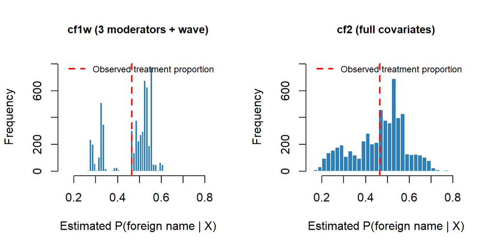

```r
# Common axes so the forests can be compared panel by panel
p_actual <- mean(W_all)    # observed share of resumes with a foreign name
x_lim    <- range(unlist(lapply(forests, function(f) f$cf$W.hat)))
y_max    <- max(sapply(forests, function(f) {
  max(hist(f$cf$W.hat, breaks = 30, plot = FALSE)$counts)
}))

par(mfrow = c(1, 2))
for (nm in names(forests)) {
  hist(forests[[nm]]$cf$W.hat,
       breaks = 30,
       col = "#2c7fb8",
       border = "white",
       main = nm,
       cex.main = 0.9,
       xlab = "Estimated P(foreign name | X)",
       xlim = x_lim,
       ylim = c(0, 1.05 * y_max))

  # Dashed line at the observed treatment share
  abline(v = p_actual, col = "red", lty = 2, lwd = 2)

  legend("topright",
         legend = "Observed treatment proportion",
         col = "red",
         lty = 2,
         lwd = 2,
         bty = "n",
         cex = 0.75)
}
```

```r
par(mfrow = c(1, 1))
```

# Causal forest results

## Average treatment effect

```r
ate_tab <- bind_rows(lapply(names(forests), function(nm) {
  a <- average_treatment_effect(forests[[nm]]$cf, target.sample = "all")
  data.frame(forest    = nm,
             effect_pp = 100 * a[["estimate"]],
             se_pp     = 100 * a[["std.err"]])
})) %>%
  mutate(lo_pp = effect_pp - 1.96 * se_pp, hi_pp = effect_pp + 1.96 * se_pp)

kable(ate_tab, digits = 3,
      caption = "Average treatment effect by forest (percentage points)")
```

Average treatment effect by forest (percentage points)

| forest | effect_pp | se_pp | lo_pp | hi_pp |
| --- | --- | --- | --- | --- |
| cf1w (3 moderators + wave) | -4.377 | 0.698 | -5.745 | -3.009 |
| cf2 (full covariates) | -4.450 | 0.742 | -5.905 | -2.995 |

```r
for (i in seq_len(nrow(ate_tab))) {
  cat(sprintf(
    paste0("**Estimated ATE, %s:** having a foreign/ethnic-sounding name changes the ",
           "callback probability by **%.3f** percentage points (SE = %.3f), ",
           "on average across the analysis sample.\n\n"),
    ate_tab$forest[i], ate_tab$effect_pp[i], ate_tab$se_pp[i]
  ))
}
```

**Estimated ATE, cf1w (3 moderators + wave):** having a foreign/ethnic-sounding name changes the callback probability by **-4.377** percentage points (SE = 0.698), on average across the analysis sample.

**Estimated ATE, cf2 (full covariates):** having a foreign/ethnic-sounding name changes the callback probability by **-4.450** percentage points (SE = 0.742), on average across the analysis sample.

## Estimated effects (CATE)

The forest’s own output: a predicted treatment effect for every resume. Read these as descriptive/exploratory unless the validation section supports heterogeneity. Compare `sd_pp` with `mean_se_pp` in the table below: when the spread of the predictions is no larger than the noise in each prediction, the spread is about what estimation noise alone would produce, so the histograms are not evidence of heterogeneity by themselves.

### Distribution of predicted effects

```r
# Exploratory distribution of out-of-bag predicted treatment effects.
# These distributions describe forest predictions and do not, by
# themselves, establish statistically significant heterogeneity.

# Obtain out-of-bag CATE predictions from both forests
cate_df <- bind_rows(lapply(names(forests), function(nm) {
  p <- predict(forests[[nm]]$cf, estimate.variance = TRUE)

  data.frame(
    forest = nm,
    tau_hat = p$predictions,
    tau_se = sqrt(p$variance.estimates)
  )
}))

# Summarise predicted CATE distributions in percentage points
cate_summary <- cate_df %>%
  group_by(forest) %>%
  summarise(
    mean_pp = 100 * mean(tau_hat),
    sd_pp = 100 * sd(tau_hat),
    min_pp = 100 * min(tau_hat),
    p25_pp = 100 * quantile(tau_hat, 0.25),
    median_pp = 100 * median(tau_hat),
    p75_pp = 100 * quantile(tau_hat, 0.75),
    max_pp = 100 * max(tau_hat),
    mean_se_pp = 100 * mean(tau_se),
    .groups = "drop"
  )

kable(
  cate_summary,
  digits = 2,
  caption = "Distribution of predicted treatment effects (pp, out-of-bag)"
)
```

Distribution of predicted treatment effects (pp, out-of-bag)

| forest | mean_pp | sd_pp | min_pp | p25_pp | median_pp | p75_pp | max_pp | mean_se_pp |
| --- | --- | --- | --- | --- | --- | --- | --- | --- |
| cf1w (3 moderators + wave) | -4.40 | 2.94 | -11.48 | -6.06 | -5.08 | -1.18 | 3.69 | 3.08 |
| cf2 (full covariates) | -4.45 | 4.70 | -18.61 | -7.53 | -4.48 | -1.00 | 8.17 | 4.73 |

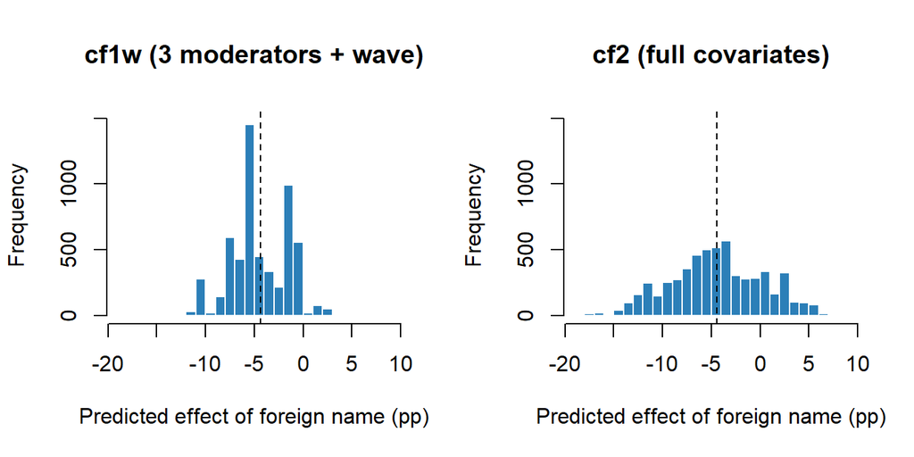

```r
# Common bins and axes so the forests can be compared panel by panel
tau_all     <- 100 * cate_df$tau_hat
cate_breaks <- seq(floor(min(tau_all)), ceiling(max(tau_all)), by = 1)
cate_ylim   <- c(0, 1.05 * max(sapply(names(forests), function(nm) {
  max(hist(100 * cate_df$tau_hat[cate_df$forest == nm],
           breaks = cate_breaks, plot = FALSE)$counts)
})))

par(mfrow = c(1, 2))
for (nm in names(forests)) {

  tau_pp <- 100 * cate_df$tau_hat[
    cate_df$forest == nm
  ]

  hist(
    tau_pp,
    breaks = cate_breaks,
    col = "#2c7fb8",
    border = "white",
    main = nm,
    xlab = "Predicted effect of foreign name (pp)",
    xlim = range(cate_breaks),
    ylim = cate_ylim
  )

  # Dashed line indicates mean predicted CATE
  abline(
    v = mean(tau_pp),
    lty = 2
  )
}
```

```r
par(mfrow = c(1, 1))
```

### Moderator table: regression and forest on the same resumes

The three pre-specified moderators are language skills, extracurricular skills and multinational experience (same_exp). For each moderator m the regression is `callback ~ D * m + wave fixed effects`, with firm-clustered (CR2) standard errors, fitted only on the resumes where m is observed. It gives the name effect when m = 0, the name effect when m = 1, and the interaction beta3 (the change in the name effect when m goes from 0 to 1), which is the formal test of whether the penalty differs. The forest columns are doubly robust ATEs from cf2 computed with `subset = !is.na(m) & m == value`, so they come from exactly the same resumes as the regression and the two sets of numbers can be compared side by side. same_exp is only observed in waves 0-1, so its rows use those waves only. This table is the main moderator result whatever the validation section finds.

```r
moderator_rows <- function(v) {
  obs   <- !is.na(df_int1[[v]])            # resumes where the moderator is observed
  dat   <- df_int1[obs, ]
  dat$y  <- as.numeric(dat$callback)
  dat$m  <- dat[[v]]
  dat$m0 <- 1 - dat$m

  # beta3: name x moderator interaction
  fit_int <- lm_robust(y ~ D * m + factor(fall_data), data = dat,
                       clusters = firmid, se_type = "CR2")
  # The same model written so the two name effects come out directly:
  # D:m0 = name effect when m = 0, D:m = name effect when m = 1
  fit_grp <- lm_robust(y ~ D:m0 + D:m + m + factor(fall_data), data = dat,
                       clusters = firmid, se_type = "CR2")

  forest_effect <- function(value) {
    idx <- which(obs & df_int1[[v]] == value)
    a   <- average_treatment_effect(cf2, subset = idx)
    c(n = length(idx), est = 100 * a[["estimate"]], se = 100 * a[["std.err"]])
  }
  f0 <- forest_effect(0)
  f1 <- forest_effect(1)

  list(
    groups = data.frame(
      moderator    = v,
      value        = c(0, 1),
      n            = c(f0[["n"]], f1[["n"]]),
      regression   = 100 * unname(coef(fit_grp)[c("D:m0", "D:m")]),
      regression_se = 100 * unname(fit_grp$std.error[c("D:m0", "D:m")]),
      forest       = c(f0[["est"]], f1[["est"]]),
      forest_se    = c(f0[["se"]], f1[["se"]])
    ),
    interaction = data.frame(
      moderator = v,
      n         = nrow(dat),
      firms     = length(unique(dat$firmid)),
      beta3_pp  = 100 * unname(coef(fit_int)["D:m"]),
      se_pp     = 100 * unname(fit_int$std.error["D:m"]),
      p         = unname(fit_int$p.value["D:m"])
    )
  )
}

moderator_res <- lapply(moderators, moderator_rows)

kable(bind_rows(lapply(moderator_res, `[[`, "groups")), digits = 2,
      col.names = c("moderator", "m", "resumes", "regression (pp)", "SE",
                    "forest cf2 (pp)", "SE"),
      caption = "Name effect by moderator value, same resumes in both columns (pp)")
```

Name effect by moderator value, same resumes in both columns (pp)

| moderator | m | resumes | regression (pp) | SE | forest cf2 (pp) | SE |
| --- | --- | --- | --- | --- | --- | --- |
| language_skills | 0 | 4233 | -4.12 | 0.84 | -4.13 | 0.89 |
| language_skills | 1 | 1424 | -5.35 | 1.68 | -5.41 | 1.83 |
| extracurricular_skills | 0 | 2240 | -6.35 | 1.30 | -6.01 | 1.39 |
| extracurricular_skills | 1 | 3417 | -3.18 | 1.01 | -3.43 | 1.07 |
| same_exp | 0 | 1899 | -5.87 | 1.28 | -5.72 | 1.36 |
| same_exp | 1 | 1498 | -2.85 | 1.56 | -2.89 | 1.69 |

```r
kable(bind_rows(lapply(moderator_res, `[[`, "interaction")), digits = 3,
      col.names = c("moderator", "resumes", "firms", "beta3 (pp)", "SE (pp)", "p"),
      caption = paste("Interaction test: change in the name effect when the",
                      "moderator goes from 0 to 1 (wave FE, firm-clustered CR2)"))
```

Interaction test: change in the name effect when the moderator goes from 0 to 1 (wave FE, firm-clustered CR2)

| moderator | resumes | firms | beta3 (pp) | SE (pp) | p |
| --- | --- | --- | --- | --- | --- |
| language_skills | 5657 | 3269 | -1.228 | 2.000 | 0.539 |
| extracurricular_skills | 5657 | 3269 | 3.171 | 1.835 | 0.084 |
| same_exp | 3397 | 1927 | 3.023 | 2.202 | 0.170 |

### Best linear projection (cf2, three moderators)

The BLP regresses cf2’s doubly robust scores on the three moderators (`A`). The other covariates still enter through cf2’s nuisance estimates; `A` only sets what the effect is summarised on. The coefficients are a joint linear approximation: they do not hold the other covariates fixed, and they need not match the one-at-a-time interaction terms above when the moderators are correlated. Resumes where any moderator is missing are excluded with `subset`, so this uses waves 0-1 (same_exp is missing in wave 2). The intercept is the effect when all three moderators are 0.

```r
A_mod  <- X_cf2[, moderators, drop = FALSE]
blp_ok <- which(complete.cases(A_mod))
cat("Resumes used:", length(blp_ok),
    "| firms:", length(unique(firm_id[blp_ok])), "\n\n")
```

```
## Resumes used: 3397 | firms: 1927
```

```r
blp <- best_linear_projection(cf2, A_mod, subset = blp_ok)
print(blp)
```

```
##
## Best linear projection of the conditional average treatment effect.
## Confidence intervals are cluster- and heteroskedasticity-robust (HC3):
##
##                         Estimate Std. Error t value  Pr(>|t|)
## (Intercept)            -0.071274   0.021627 -3.2955 0.0009925 ***
## language_skills         0.029369   0.030662  0.9578 0.3382153
## extracurricular_skills  0.013059   0.025324  0.5157 0.6061137
## same_exp                0.028823   0.023597  1.2215 0.2219979
## ---
## Signif. codes:  0 '***' 0.001 '**' 0.01 '*' 0.05 '.' 0.1 ' ' 1
```

### Predicted effect by covariate cell (cf1w)

cf1w has only a few distinct covariate combinations, so show them directly (same_exp = NA is wave 2).

```r
cf1w_cells <- df_int1 %>%
  mutate(tau_hat = predict(cf1w)$predictions) %>%
  group_by(language_skills, extracurricular_skills, same_exp) %>%
  summarise(n = n(), effect_pp = 100 * mean(tau_hat), .groups = "drop") %>%
  arrange(effect_pp)

kable(cf1w_cells, digits = 2, caption = "cf1w: predicted effect by covariate cell (pp)")
```

cf1w: predicted effect by covariate cell (pp)

| language_skills | extracurricular_skills | same_exp | n | effect_pp |
| --- | --- | --- | --- | --- |
| 1 | 0 | NA | 308 | -10.72 |
| 1 | 0 | 0 | 162 | -7.00 |
| 0 | 0 | 0 | 597 | -6.88 |
| 0 | 0 | NA | 571 | -5.21 |
| 1 | 1 | NA | 422 | -5.04 |
| 0 | 1 | 0 | 900 | -4.83 |
| 0 | 0 | 1 | 494 | -4.81 |
| 1 | 1 | 1 | 184 | -4.03 |
| 0 | 1 | 1 | 712 | -3.28 |
| 1 | 1 | 0 | 240 | -2.01 |
| 0 | 1 | NA | 959 | -1.10 |
| 1 | 0 | 1 | 108 | 0.96 |

# Validation of causal forest results

## test_calibration

The differential forest prediction is the number that matters. grf’s p-value on it is one-sided (is the coefficient above zero?). Near 1 means well calibrated, between 0 and 1 means the forest overstates the spread, and at or below 0 means the spread isn’t tracking real differences.

```r
calibration <- lapply(forests, function(f) test_calibration(f$cf))

for (nm in names(calibration)) {
  cat("\n====", nm, "====\n")
  print(calibration[[nm]])
}
```

```
##
## ==== cf1w (3 moderators + wave) ====
##
## Best linear fit using forest predictions (on held-out data)
## as well as the mean forest prediction as regressors, along
## with one-sided heteroskedasticity-robust (HC3) SEs:
##
##                                Estimate Std. Error t value    Pr(>t)
## mean.forest.prediction          0.99453    0.15804  6.2931 1.673e-10 ***
## differential.forest.prediction -0.18527    0.30052 -0.6165    0.7312
## ---
## Signif. codes:  0 '***' 0.001 '**' 0.01 '*' 0.05 '.' 0.1 ' ' 1
##
##
## ==== cf2 (full covariates) ====
##
## Best linear fit using forest predictions (on held-out data)
## as well as the mean forest prediction as regressors, along
## with one-sided heteroskedasticity-robust (HC3) SEs:
##
##                                 Estimate Std. Error t value    Pr(>t)
## mean.forest.prediction         0.9979018  0.1585777  6.2928 1.676e-10 ***
## differential.forest.prediction 0.0097972  0.1888274  0.0519    0.4793
## ---
## Signif. codes:  0 '***' 0.001 '**' 0.01 '*' 0.05 '.' 0.1 ' ' 1
```

```r
cal_tab <- bind_rows(lapply(names(calibration), function(nm) {
  tc <- calibration[[nm]]
  data.frame(
    forest           = nm,
    mean_est         = tc["mean.forest.prediction", "Estimate"],
    mean_se          = tc["mean.forest.prediction", "Std. Error"],
    diff_est         = tc["differential.forest.prediction", "Estimate"],
    diff_se          = tc["differential.forest.prediction", "Std. Error"],
    diff_p_one_sided = tc["differential.forest.prediction", "Pr(>t)"]
  )
}))

kable(cal_tab, digits = 3, caption = "test_calibration results")
```

test_calibration results

| forest | mean_est | mean_se | diff_est | diff_se | diff_p_one_sided |
| --- | --- | --- | --- | --- | --- |
| cf1w (3 moderators + wave) | 0.995 | 0.158 | -0.185 | 0.301 | 0.731 |
| cf2 (full covariates) | 0.998 | 0.159 | 0.010 | 0.189 | 0.479 |

## RATE / TOC with a firm-level split

Half of the firms train a forest that produces the priority scores; the other half trains a separate evaluation forest. The split is by firm, not by resume, so resumes from one employer never sit on both sides. AUTOC is the primary measure and QINI the secondary one, chosen in advance. The priority score is the forest’s predicted effect with no sign flip, so the top of the ranking is the group with the smallest predicted penalty (the least negative effects), and a positive RATE means the ranking sorts correctly.

Seed 1 is the headline split, fixed in advance. Seeds 2 to `n_seeds` are stability checks only. This chunk fits many forests and can take a few minutes.

```r
n_seeds <- 5

make_split <- function(firm, seed) {
  set.seed(seed)    # set immediately before sampling so the split is reproducible
  f <- unique(firm)
  firm %in% sample(f, floor(length(f) / 2))
}

# Train on one half of the firms and evaluate on the other half.
# `targets` picks the RATE measures to compute (one list element each: autoc, qini).
# `...` passes extra arguments (e.g. tuning settings) to causal_forest.
# The RATE standard errors are bootstrapped, so computing extra targets uses up
# random draws; the tuning check asks for AUTOC only so its draws stay unchanged.
run_rate <- function(X, Y, W, firm, train, seed, targets = c("AUTOC", "QINI"), ...) {
  cf_train <- causal_forest(X[train, , drop = FALSE],  Y[train],  W[train],
                            clusters = firm[train],  seed = seed, ...)
  cf_eval  <- causal_forest(X[!train, , drop = FALSE], Y[!train], W[!train],
                            clusters = firm[!train], seed = seed, ...)
  priorities <- predict(cf_train, X[!train, , drop = FALSE])$predictions
  rates <- lapply(targets, function(tg) {
    rank_average_treatment_effect(cf_eval, priorities, target = tg)
  })
  setNames(rates, tolower(targets))
}

rate_res <- lapply(forests, function(f) {
  out <- lapply(seq_len(n_seeds), function(s) {
    train <- make_split(firm_id, s)
    run_rate(f$X, Y_all, W_all, firm_id, train, seed = s)
  })
  names(out) <- seq_len(n_seeds)
  out
})

rate_tab <- bind_rows(lapply(names(rate_res), function(nm) {
  bind_rows(lapply(names(rate_res[[nm]]), function(s) {
    a <- rate_res[[nm]][[s]]$autoc
    q <- rate_res[[nm]][[s]]$qini
    data.frame(forest = nm, seed = as.integer(s), headline = (s == "1"),
               autoc = a$estimate, autoc_se = a$std.err,
               autoc_lo = a$estimate - 1.96 * a$std.err,
               autoc_hi = a$estimate + 1.96 * a$std.err,
               qini = q$estimate, qini_se = q$std.err)
  }))
}))

rate_tab %>%
  mutate(forest = short_name(forest)) %>%
  kable(digits = 4, caption = "RATE by forest and split seed (headline = seed 1)")
```

RATE by forest and split seed (headline = seed 1)

| forest | seed | headline | autoc | autoc_se | autoc_lo | autoc_hi | qini | qini_se |
| --- | --- | --- | --- | --- | --- | --- | --- | --- |
| cf1w | 1 | TRUE | -0.0063 | 0.0102 | -0.0262 | 0.0137 | -0.0027 | 0.0036 |
| cf1w | 2 | FALSE | -0.0082 | 0.0100 | -0.0278 | 0.0114 | -0.0012 | 0.0032 |
| cf1w | 3 | FALSE | 0.0004 | 0.0107 | -0.0206 | 0.0214 | -0.0016 | 0.0035 |
| cf1w | 4 | FALSE | 0.0155 | 0.0104 | -0.0049 | 0.0360 | 0.0063 | 0.0033 |
| cf1w | 5 | FALSE | -0.0086 | 0.0110 | -0.0302 | 0.0130 | -0.0011 | 0.0034 |
| cf2 | 1 | TRUE | -0.0050 | 0.0131 | -0.0306 | 0.0206 | -0.0027 | 0.0039 |
| cf2 | 2 | FALSE | -0.0133 | 0.0110 | -0.0349 | 0.0083 | -0.0053 | 0.0030 |
| cf2 | 3 | FALSE | 0.0084 | 0.0104 | -0.0121 | 0.0288 | 0.0042 | 0.0037 |
| cf2 | 4 | FALSE | 0.0147 | 0.0118 | -0.0084 | 0.0379 | 0.0034 | 0.0034 |
| cf2 | 5 | FALSE | -0.0082 | 0.0128 | -0.0333 | 0.0169 | -0.0008 | 0.0036 |

TOC curves for the headline split. The three-moderator forest (cf1w) can produce only a few distinct predictions, so many resumes are tied in the ranking and its curve will look stepped; mention this in the write-up.

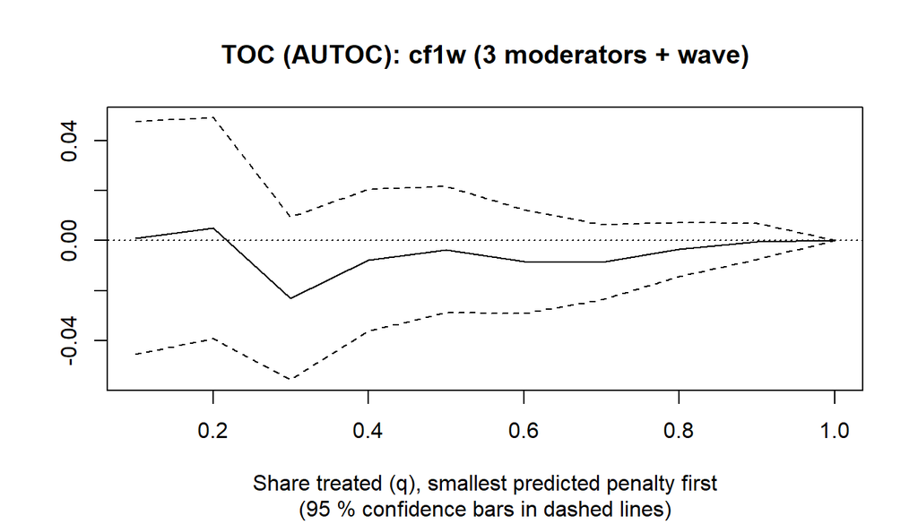

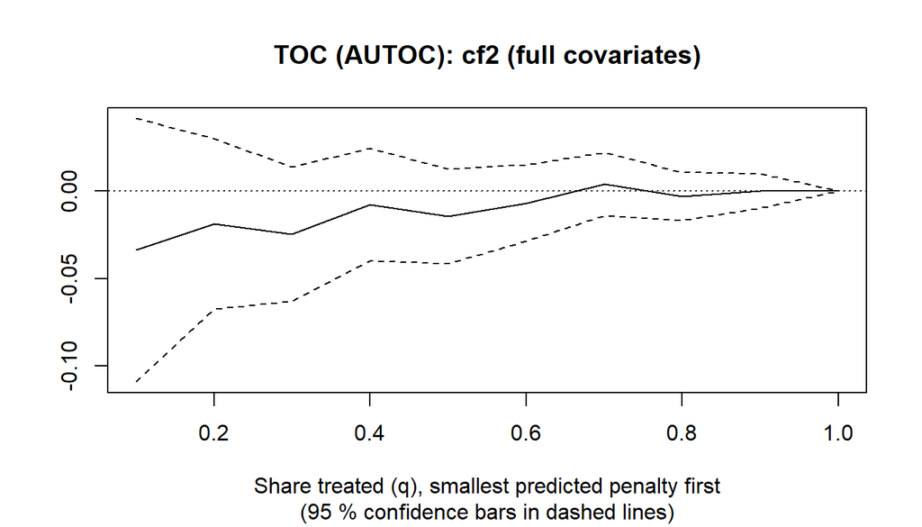

```r
for (nm in names(rate_res)) {
  plot(rate_res[[nm]][["1"]]$autoc, main = paste("TOC (AUTOC):", nm),
       xlab = "Share treated (q), smallest predicted penalty first")
}
```

## Combined reading (rule fixed in advance)

Both checks support heterogeneity: calibration differential coefficient positive and significant (one-sided p < 0.05) and the headline AUTOC interval excluding 0. Neither supports it: report that we find no statistically reliable evidence of heterogeneity, and do not interpret forest subgroup patterns. They disagree: call the evidence inconclusive and treat any subgroup patterns as exploratory only. A null here may reflect low power, not constant effects. If the verdict is a null, covariate means across held-out priority groups are not reported: that descriptive step is only meaningful when the RATE is clearly non-zero.

```r
verdict_tab <- cal_tab %>%
  left_join(filter(rate_tab, headline), by = "forest") %>%
  mutate(
    calibration_supports = diff_p_one_sided < 0.05,
    rate_supports        = autoc_lo > 0,
    verdict = case_when(
      calibration_supports & rate_supports   ~ "Both support heterogeneity",
      !calibration_supports & !rate_supports ~ "Neither supports: report null",
      TRUE                                   ~ "Disagree: inconclusive"
    )
  ) %>%
  select(forest, diff_est, diff_se, diff_p_one_sided,
         autoc, autoc_lo, autoc_hi, verdict)

verdict_tab %>%
  mutate(forest = short_name(forest)) %>%
  kable(digits = 3, caption = "Validation verdict by forest",
        col.names = c("Forest", "Diff. est.", "Diff. SE", "p (1-sided)",
                      "AUTOC", "AUTOC lo", "AUTOC hi", "Verdict"))
```

Validation verdict by forest

| Forest | Diff. est. | Diff. SE | p (1-sided) | AUTOC | AUTOC lo | AUTOC hi | Verdict |
| --- | --- | --- | --- | --- | --- | --- | --- |
| cf1w | -0.185 | 0.301 | 0.731 | -0.006 | -0.026 | 0.014 | Neither supports: report null |
| cf2 | 0.010 | 0.189 | 0.479 | -0.005 | -0.031 | 0.021 | Neither supports: report null |

## Tuning robustness

One alternative setting, fixed in advance: twice the default trees (4000 vs 2000) and a larger honesty fraction (0.7 vs the grf default 0.5). It is not a grid. The question is only whether the null verdict changes. Seed 1 is the same firm split as the headline RATE result, so the comparison is like for like.

```r
alt <- list(num.trees = 4000, honesty.fraction = 0.7)

# Calibration under the alternative setting
forests_alt <- lapply(forests, function(f) {
  causal_forest(f$X, Y_all, W_all,
                clusters         = firm_id,
                num.trees        = alt$num.trees,
                honesty.fraction = alt$honesty.fraction,
                seed             = 123)
})

cal_alt <- bind_rows(lapply(names(forests_alt), function(nm) {
  tc <- test_calibration(forests_alt[[nm]])
  data.frame(
    forest           = nm,
    diff_est         = tc["differential.forest.prediction", "Estimate"],
    diff_se          = tc["differential.forest.prediction", "Std. Error"],
    diff_p_one_sided = tc["differential.forest.prediction", "Pr(>t)"]
  )
}))

# AUTOC under the alternative setting (headline split, seed 1)
train_1 <- make_split(firm_id, 1)

rate_alt_tab <- bind_rows(lapply(names(forests), function(nm) {
  a <- run_rate(forests[[nm]]$X, Y_all, W_all, firm_id, train_1, seed = 1,
                targets          = "AUTOC",
                num.trees        = alt$num.trees,
                honesty.fraction = alt$honesty.fraction)$autoc
  data.frame(forest   = nm,
             autoc    = a$estimate,
             autoc_lo = a$estimate - 1.96 * a$std.err,
             autoc_hi = a$estimate + 1.96 * a$std.err)
}))

# Default vs alternative
stab_tab <- cal_tab %>%
  select(forest, diff_default = diff_est, p_default = diff_p_one_sided) %>%
  left_join(select(cal_alt, forest, diff_alt = diff_est, p_alt = diff_p_one_sided),
            by = "forest") %>%
  left_join(filter(rate_tab, headline) %>%
              select(forest, autoc_default = autoc,
                     lo_default = autoc_lo, hi_default = autoc_hi),
            by = "forest") %>%
  left_join(select(rate_alt_tab, forest, autoc_alt = autoc,
                   lo_alt = autoc_lo, hi_alt = autoc_hi),
            by = "forest")

stab_tab %>%
  mutate(forest = short_name(forest)) %>%
  kable(digits = 3,
        caption = "Default vs alternative tuning (4000 trees, honesty fraction 0.7)",
        col.names = c("Forest", "Diff (def)", "p (def)", "Diff (alt)", "p (alt)",
                      "AUTOC (def)", "Lo (def)", "Hi (def)",
                      "AUTOC (alt)", "Lo (alt)", "Hi (alt)"))
```

Default vs alternative tuning (4000 trees, honesty fraction 0.7)

| Forest | Diff (def) | p (def) | Diff (alt) | p (alt) | AUTOC (def) | Lo (def) | Hi (def) | AUTOC (alt) | Lo (alt) | Hi (alt) |
| --- | --- | --- | --- | --- | --- | --- | --- | --- | --- | --- |
| cf1w | -0.185 | 0.731 | -0.186 | 0.737 | -0.006 | -0.026 | 0.014 | -0.007 | -0.026 | 0.013 |
| cf2 | 0.010 | 0.479 | 0.058 | 0.358 | -0.005 | -0.031 | 0.021 | -0.012 | -0.038 | 0.014 |

Reading it: the verdict is stable if every forest still has a calibration p above 0.05 and an AUTOC interval that includes 0 under the alternative setting. If one forest flips, report it as sensitive to tuning and treat the evidence for that forest as inconclusive under your combined rule.